# Capstone Quiz I

Complete all **Exercises**, and submit answers to **Questions** on the Coursera platform.

```r
library(devtools)
library(dplyr)
library(statsr)
library(ggplot2)
```

This initial quiz will concern exploratory data analysis (EDA) of the Ames Housing dataset. EDA is essential when working with any source of data and helps inform modeling.

First, let us load the data:

```r
load("ames_train.Rdata")
```

1. Which of the following are the three variables with the highest number of missing observations?
   1. `Misc.Feature`, `Fence`, `Pool.QC`
   2. `Misc.Feature`, `Alley`, `Pool.QC`
   3. `Pool.QC`, `Alley`, `Fence`
   4. `Fireplace.Qu`, `Pool.QC`, `Lot.Frontage`

```r
# type your code for Question 1 here, and Knit
sort(colSums(is.na(ames_train)), decreasing = TRUE)
```

```
##         Pool.QC    Misc.Feature           Alley           Fence
##             997             971             933             798
##    Fireplace.Qu    Lot.Frontage   Garage.Yr.Blt     Garage.Qual
##             491             167              48              47
##     Garage.Cond     Garage.Type   Garage.Finish       Bsmt.Qual
##              47              46              46              21
##       Bsmt.Cond   Bsmt.Exposure  BsmtFin.Type.1  BsmtFin.Type.2
##              21              21              21              21
##    Mas.Vnr.Area    BsmtFin.SF.1    BsmtFin.SF.2     Bsmt.Unf.SF
##               7               1               1               1
##   Total.Bsmt.SF  Bsmt.Full.Bath  Bsmt.Half.Bath     Garage.Cars
##               1               1               1               1
##     Garage.Area             PID            area           price
##               1               0               0               0
##     MS.SubClass       MS.Zoning        Lot.Area          Street
##               0               0               0               0
##       Lot.Shape    Land.Contour       Utilities      Lot.Config
##               0               0               0               0
##      Land.Slope    Neighborhood     Condition.1     Condition.2
##               0               0               0               0
##       Bldg.Type     House.Style    Overall.Qual    Overall.Cond
##               0               0               0               0
##      Year.Built  Year.Remod.Add      Roof.Style       Roof.Matl
##               0               0               0               0
##    Exterior.1st    Exterior.2nd    Mas.Vnr.Type      Exter.Qual
##               0               0               0               0
##      Exter.Cond      Foundation         Heating      Heating.QC
##               0               0               0               0
##     Central.Air      Electrical     X1st.Flr.SF     X2nd.Flr.SF
##               0               0               0               0
## Low.Qual.Fin.SF       Full.Bath       Half.Bath   Bedroom.AbvGr
##               0               0               0               0
##   Kitchen.AbvGr    Kitchen.Qual   TotRms.AbvGrd      Functional
##               0               0               0               0
##      Fireplaces     Paved.Drive    Wood.Deck.SF   Open.Porch.SF
##               0               0               0               0
##  Enclosed.Porch     X3Ssn.Porch    Screen.Porch       Pool.Area
##               0               0               0               0
##        Misc.Val         Mo.Sold         Yr.Sold       Sale.Type
##               0               0               0               0
##  Sale.Condition
##               0
```

2. How many categorical variables are coded in R as having type `int`? Change them to factors when conducting your analysis.
   1. 0
   2. 1
   3. 2
   4. 3

```r
# type your code for Question 2 here, and Knit
str(select_if(ames_train, is.numeric))
```

```
## Classes 'tbl_df', 'tbl' and 'data.frame':    1000 obs. of  38 variables:
##  $ PID            : int  909176150 905476230 911128020 535377150 534177230 908128060 902135020 528228540 923426010 908186050 ...
##  $ area           : int  856 1049 1001 1039 1665 1922 936 1246 889 1072 ...
##  $ price          : int  126000 139500 124900 114000 227000 198500 93000 187687 137500 140000 ...
##  $ MS.SubClass    : int  30 120 30 70 60 85 20 20 20 180 ...
##  $ Lot.Frontage   : int  NA 42 60 80 70 64 60 53 74 35 ...
##  $ Lot.Area       : int  7890 4235 6060 8146 8400 7301 6000 3710 12395 3675 ...
##  $ Overall.Qual   : int  6 5 5 4 8 7 4 7 5 6 ...
##  $ Overall.Cond   : int  6 5 9 8 6 5 4 5 6 5 ...
##  $ Year.Built     : int  1939 1984 1930 1900 2001 2003 1953 2007 1984 2005 ...
##  $ Year.Remod.Add : int  1950 1984 2007 2003 2001 2003 1953 2008 1984 2005 ...
##  $ Mas.Vnr.Area   : int  0 149 0 0 0 500 0 20 0 76 ...
##  $ BsmtFin.SF.1   : int  238 552 737 0 643 0 0 0 647 467 ...
##  $ BsmtFin.SF.2   : int  0 393 0 0 0 0 0 0 0 0 ...
##  $ Bsmt.Unf.SF    : int  618 104 100 405 167 0 936 1146 217 80 ...
```

[output cut: 24 more lines]

```r
summary(select_if(ames_train, is.numeric))
```

```
##       PID                 area          price         MS.SubClass
##  Min.   :5.263e+08   Min.   : 334   Min.   : 12789   Min.   : 20.00
##  1st Qu.:5.285e+08   1st Qu.:1092   1st Qu.:129763   1st Qu.: 20.00
##  Median :5.354e+08   Median :1411   Median :159467   Median : 50.00
##  Mean   :7.059e+08   Mean   :1477   Mean   :181190   Mean   : 57.15
##  3rd Qu.:9.071e+08   3rd Qu.:1743   3rd Qu.:213000   3rd Qu.: 70.00
##  Max.   :1.007e+09   Max.   :4676   Max.   :615000   Max.   :190.00
##
##   Lot.Frontage       Lot.Area       Overall.Qual     Overall.Cond
##  Min.   : 21.00   Min.   :  1470   Min.   : 1.000   Min.   :1.000
##  1st Qu.: 57.00   1st Qu.:  7314   1st Qu.: 5.000   1st Qu.:5.000
##  Median : 69.00   Median :  9317   Median : 6.000   Median :5.000
##  Mean   : 69.21   Mean   : 10352   Mean   : 6.095   Mean   :5.559
##  3rd Qu.: 80.00   3rd Qu.: 11650   3rd Qu.: 7.000   3rd Qu.:6.000
##  Max.   :313.00   Max.   :215245   Max.   :10.000   Max.   :9.000
##  NA's   :167
##    Year.Built   Year.Remod.Add  Mas.Vnr.Area     BsmtFin.SF.1
##  Min.   :1872   Min.   :1950   Min.   :   0.0   Min.   :   0.0
##  1st Qu.:1955   1st Qu.:1966   1st Qu.:   0.0   1st Qu.:   0.0
##  Median :1975   Median :1992   Median :   0.0   Median : 400.0
##  Mean   :1972   Mean   :1984   Mean   : 104.1   Mean   : 464.1
##  3rd Qu.:2001   3rd Qu.:2004   3rd Qu.: 160.0   3rd Qu.: 773.0
##  Max.   :2010   Max.   :2010   Max.   :1290.0   Max.   :2260.0
##                                NA's   :7        NA's   :1
##   BsmtFin.SF.2      Bsmt.Unf.SF     Total.Bsmt.SF     X1st.Flr.SF
##  Min.   :   0.00   Min.   :   0.0   Min.   :   0.0   Min.   : 334.0
##  1st Qu.:   0.00   1st Qu.: 223.5   1st Qu.: 797.5   1st Qu.: 876.2
##  Median :   0.00   Median : 461.0   Median : 998.0   Median :1080.5
##  Mean   :  48.07   Mean   : 547.0   Mean   :1059.2   Mean   :1157.1
##  3rd Qu.:   0.00   3rd Qu.: 783.0   3rd Qu.:1301.0   3rd Qu.:1376.2
##  Max.   :1526.00   Max.   :2336.0   Max.   :3138.0   Max.   :3138.0
##  NA's   :1         NA's   :1        NA's   :1
##   X2nd.Flr.SF     Low.Qual.Fin.SF   Bsmt.Full.Bath   Bsmt.Half.Bath
##  Min.   :   0.0   Min.   :   0.00   Min.   :0.0000   Min.   :0.00000
##  1st Qu.:   0.0   1st Qu.:   0.00   1st Qu.:0.0000   1st Qu.:0.00000
##  Median :   0.0   Median :   0.00   Median :0.0000   Median :0.00000
##  Mean   : 315.2   Mean   :   4.32   Mean   :0.4474   Mean   :0.06106
##  3rd Qu.: 688.2   3rd Qu.:   0.00   3rd Qu.:1.0000   3rd Qu.:0.00000
##  Max.   :1836.0   Max.   :1064.00   Max.   :3.0000   Max.   :2.00000
##                                     NA's   :1        NA's   :1
```

[output cut: 25 more lines]

```
##  Min.   :  0.000   Min.   :  0.00   Min.   :  0.000   Min.   :    0.00
##  1st Qu.:  0.000   1st Qu.:  0.00   1st Qu.:  0.000   1st Qu.:    0.00
##  Median :  0.000   Median :  0.00   Median :  0.000   Median :    0.00
##  Mean   :  3.118   Mean   : 14.77   Mean   :  1.463   Mean   :   45.81
##  3rd Qu.:  0.000   3rd Qu.:  0.00   3rd Qu.:  0.000   3rd Qu.:    0.00
##  Max.   :508.000   Max.   :440.00   Max.   :800.000   Max.   :15500.00
##
##     Mo.Sold          Yr.Sold
##  Min.   : 1.000   Min.   :2006
##  1st Qu.: 4.000   1st Qu.:2007
##  Median : 6.000   Median :2008
##  Mean   : 6.243   Mean   :2008
##  3rd Qu.: 8.000   3rd Qu.:2009
##  Max.   :12.000   Max.   :2010
##
```

3. In terms of price, which neighborhood has the highest standard deviation?
   1. `StoneBr`
   2. `Timber`
   3. `Veenker`
   4. `NridgHt`

```r
# type your code for Question 3 here, and Knit
ames_train %>%
  group_by(Neighborhood) %>%
  summarize(sd_price = sd(price)) %>%
  arrange(desc(sd_price)) %>%
  top_n(10, wt = sd_price)
```

```
## # A tibble: 10 x 2
##    Neighborhood sd_price
##    <fct>           <dbl>
##  1 StoneBr       123459.
##  2 NridgHt       105089.
##  3 Timber         84030.
##  4 Veenker        72545.
##  5 Crawfor        71268.
##  6 GrnHill        70711.
##  7 Somerst        65199.
##  8 Edwards        54852.
##  9 CollgCr        52786.
## 10 SawyerW        48354.
```

4. Using scatter plots or other graphical displays, which of the following variables appears to be the best single predictor of `price`?
   1. `Lot.Area`
   2. `Bedroom.AbvGr`
   3. `Overall.Qual`
   4. `Year.Built`

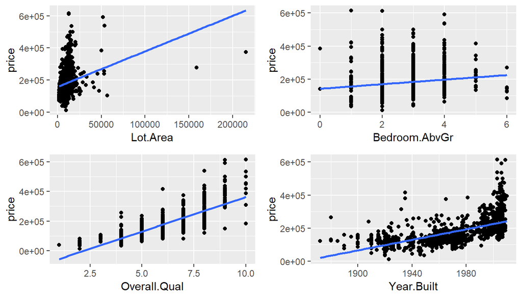

```r
# type your code for Question 4 here, and Knit
p1 <- ggplot(data = ames_train, aes(x = Lot.Area, y = price)) +
  geom_point() +
  stat_smooth(method = "lm", se = FALSE)
p2 <- ggplot(data = ames_train, aes(x = Bedroom.AbvGr, y = price)) +
  geom_point() +
  stat_smooth(method = "lm", se = FALSE)
p3 <- ggplot(data = ames_train, aes(x = Overall.Qual, y = price)) +
  geom_point() +
  stat_smooth(method = "lm", se = FALSE)
p4 <- ggplot(data = ames_train, aes(x = Year.Built, y = price)) +
  geom_point() +
  stat_smooth(method = "lm", se = FALSE)

gridExtra::grid.arrange(p1, p2, p3, p4, ncol = 2)
```

5. Suppose you are examining the relationship between `price` and `area`. Which of the following variable transformations makes the relationship appear to be the most linear?
   1. Do not transform either `price` or `area`
   2. Log-transform `price` but not `area`
   3. Log-transform `area` but not `price`
   4. Log-transform both `price` and `area`

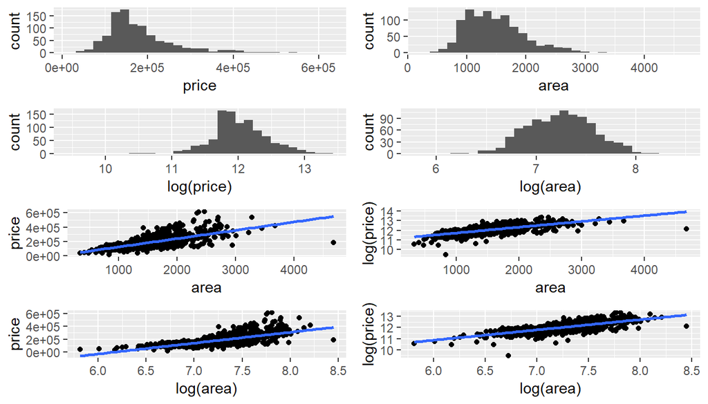

```r
# type your code for Question 5 here, and Knit
price_hist <- ggplot(data=ames_train, aes(price)) +
  geom_histogram()
area_hist <- ggplot(data=ames_train, aes(area)) +
  geom_histogram()
lprice_hist <- ggplot(data=ames_train, aes(log(price))) +
  geom_histogram()
larea_hist <- ggplot(data=ames_train, aes(log(area))) +
  geom_histogram()
price_area_scatter <- ggplot(data=ames_train, aes(x = area, y = price)) +
  geom_point() +
  stat_smooth(method = "lm", se = FALSE)
lprice_area_scatter <- ggplot(data=ames_train, aes(x = area, y = log(price))) +
  geom_point() +
  stat_smooth(method = "lm", se = FALSE)
price_larea_scatter <- ggplot(data=ames_train, aes(x = log(area), y = price)) +
  geom_point() +
  stat_smooth(method = "lm", se = FALSE)
lprice_larea_scatter <- ggplot(data=ames_train, aes(x = log(area), y = log(price))) +
  geom_point() +
  stat_smooth(method = "lm", se = FALSE)
gridExtra::grid.arrange(price_hist, area_hist, lprice_hist, larea_hist,
                        price_area_scatter, lprice_area_scatter, price_larea_scatter, lprice_larea_scatter,
                        ncol = 2)
```

6. Suppose that your prior for the proportion of houses that have at least one garage is Beta(9, 1). What is your posterior? Assume a beta-binomial model for this proportion.
   1. Beta(954, 46)
   2. Beta(963, 46)
   3. Beta(954, 47)
   4. Beta(963, 47)

```r
# type your code for Question 6 here, and Knit
ames_train %>%
  mutate(at_least_one_garage = ifelse(!is.na(Garage.Type), 1, 0)) %>%
  dplyr::select(at_least_one_garage) %>%
  group_by(at_least_one_garage) %>%
  summarise(count = n())
```

```
## # A tibble: 2 x 2
##   at_least_one_garage count
##                 <dbl> <int>
## 1                   0    46
## 2                   1   954
```

7. Which of the following statements is true about the dataset?
   1. Over 30 percent of houses were built after the year 1999.
   2. The median housing price is greater than the mean housing price.
   3. 21 houses do not have a basement.
   4. 4 houses are located on gravel streets.

```r
# type your code for Question 7 here, and Knit
ames_train %>%
  mutate(after_1999 = ifelse(Year.Built > 1999, 1, 0)) %>%
  group_by(after_1999) %>%
  summarise(n = n()) %>%
  mutate(freq = n / sum(n))
```

```
## # A tibble: 2 x 3
##   after_1999     n  freq
##        <dbl> <int> <dbl>
## 1          0   728 0.728
## 2          1   272 0.272
```

```r
summary(ames_train$price)
```

```
##    Min. 1st Qu.  Median    Mean 3rd Qu.    Max.
##   12789  129763  159467  181190  213000  615000
```

```r
ames_train %>%
  mutate(no_bsmt = ifelse(Total.Bsmt.SF == 0, 1, 0)) %>%
  group_by(no_bsmt) %>%
  summarise(count = n())
```

```
## # A tibble: 3 x 2
##   no_bsmt count
##     <dbl> <int>
## 1       0   978
## 2       1    21
## 3      NA     1
```

```r
ames_train %>%
  group_by(Street) %>%
  summarise(count = n())
```

```
## # A tibble: 2 x 2
##   Street count
##   <fct>  <int>
## 1 Grvl       3
## 2 Pave     997
```

8. Test, at the $\alpha = 0.05$ level, whether homes with a garage have larger square footage than those without a garage.
   1. With a p-value near 0.000, we reject the null hypothesis of no difference.
   2. With a p-value of approximately 0.032, we reject the null hypothesis of no difference.
   3. With a p-value of approximately 0.135, we fail to reject the null hypothesis of no difference.
   4. With a p-value of approximately 0.343, we fail to reject the null hypothesis of no difference.

```r
# type your code for Question 8 here, and Knit
with_garage_ames <- ames_train %>%
  mutate(with_garage = factor(ifelse(!is.na(Garage.Type), "Yes", "No"))) %>%
  dplyr::select(with_garage, area)
inference(y = area, x = with_garage, data = with_garage_ames, null = 0, statistic = "mean", type = "ht", method = "theoretical", alternative = "less")
```

```
## Response variable: numerical
## Explanatory variable: categorical (2 levels)
## n_No = 46, y_bar_No = 1145.0435, s_No = 445.1805
## n_Yes = 954, y_bar_Yes = 1492.6027, s_Yes = 502.5917
## H0: mu_No =  mu_Yes
## HA: mu_No < mu_Yes
## t = -5.1395, df = 45
## p_value = < 0.0001
```

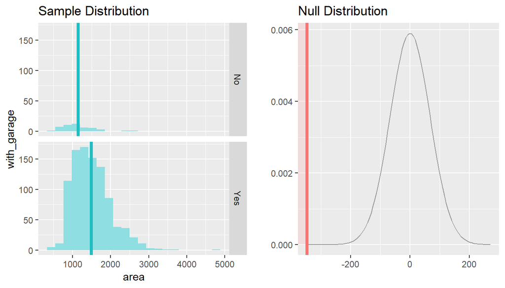

9. For homes with square footage greater than 2000, assume that the number of bedrooms above ground follows a Poisson distribution with rate $\lambda$. Your prior on $\lambda$ follows a Gamma distribution with mean 3 and standard deviation 1. What is your posterior mean and standard deviation for the average number of bedrooms in houses with square footage greater than 2000 square feet?
   1. Mean: 3.61, SD: 0.11
   2. Mean: 3.62, SD: 0.16
   3. Mean: 3.63, SD: 0.09
   4. Mean: 3.63, SD: 0.91

```r
# type your code for Question 9 here, and Knit
ames_train %>%
  mutate(greater_than_2000 = factor(ifelse(area > 2000, "Yes", "No"))) %>%
  dplyr::select(greater_than_2000, Bedroom.AbvGr) %>%
  group_by(greater_than_2000) %>%
  summarise(n = n(), sum = sum(Bedroom.AbvGr))
```

```
## # A tibble: 2 x 3
##   greater_than_2000     n   sum
##   <fct>             <int> <int>
## 1 No                  862  2305
## 2 Yes                 138   501
```

```r
k <- 9
theta <- 1 / 3
k_s <- k + 501
theta_s <- theta / (138 * theta + 1)
k_s * theta_s
```

```
## [1] 3.617021
```

```r
theta_s * sqrt(k_s)
```

```
## [1] 0.1601644
```

10. When regressing $\log$(`price`) on $\log$(`area`), there are some outliers. Which of the following do the three most outlying points have in common?
    1. They had abnormal sale conditions.
    2. They have only two bedrooms.
    3. They have an overall quality of less than 3.
    4. They were built before 1930.

```r
# type your code for Question 10 here, and Knit
m_price_area <- lm(log(price) ~ log(area), data = ames_train)
outliers <- BAS::Bayes.outlier(m_price_area, k = 3)
outliers_df <- data.frame(probability = outliers$prob.outlier,
                          case = 1:length(outliers$prob.outlier))
outliers_index <- c(which(outliers_df$probability > 0.999))

ames_train %>%
  slice(outliers_index) %>%
  group_by(Sale.Condition) %>%
  summarise(n = n())
```

```
## # A tibble: 3 x 2
##   Sale.Condition     n
##   <fct>          <int>
## 1 Abnorml            3
## 2 Normal             1
## 3 Partial            1
```

```r
ames_train %>%
  slice(outliers_index) %>%
  group_by(Bedroom.AbvGr) %>%
  summarise(n = n())
```

```
## # A tibble: 2 x 2
##   Bedroom.AbvGr     n
##           <int> <int>
## 1             2     2
## 2             3     3
```

```r
ames_train %>%
  slice(outliers_index) %>%
  group_by(Overall.Qual) %>%
  summarise(n = n())
```

```
## # A tibble: 3 x 2
##   Overall.Qual     n
##          <int> <int>
## 1            2     1
## 2            4     3
## 3           10     1
```

```r
ames_train %>%
  slice(outliers_index) %>%
  group_by(Year.Built) %>%
  summarise(n = n())
```

```
## # A tibble: 4 x 2
##   Year.Built     n
##        <int> <int>
## 1       1910     1
## 2       1920     2
## 3       1923     1
## 4       2007     1
```

11. Which of the following are reasons to log-transform `price` if used as a dependent variable in a linear regression?
    1. `price` is right-skewed.
    2. `price` cannot take on negative values.
    3. `price` can only take on integer values.
    4. Both a and b.

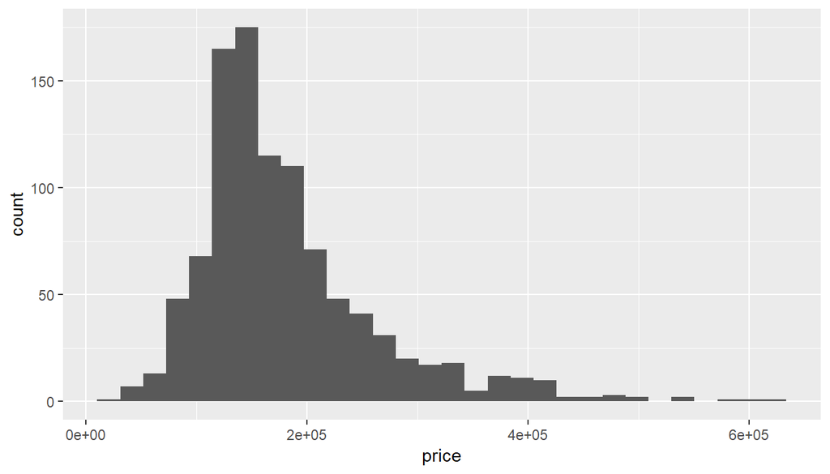

```r
# type your code for Question 11 here, and Knit
ggplot(data = ames_train, aes(price)) +
  geom_histogram()
```

12. How many neighborhoods consist of only single-family homes? (e.g. `Bldg.Type` = `1Fam`)
    1. 0
    2. 1
    3. 2
    4. 3

```r
# type your code for Question 12 here, and Knit
ames_train %>%
  group_by(Neighborhood) %>%
  summarise(freq = mean(Bldg.Type == "1Fam")) %>%
  arrange(desc(freq)) %>%
  top_n(5, wt = freq)
```

```
## # A tibble: 6 x 2
##   Neighborhood  freq
##   <fct>        <dbl>
## 1 ClearCr      1
## 2 NoRidge      1
## 3 Timber       1
## 4 Gilbert      0.980
## 5 BrkSide      0.976
## 6 NWAmes       0.976
```

13. Using color, different plotting symbols, conditioning plots, etc., does there appear to be an association between $\log$(`area`) and the number of bedrooms above ground (`Bedroom.AbvGr`)?
    1. Yes
    2. No

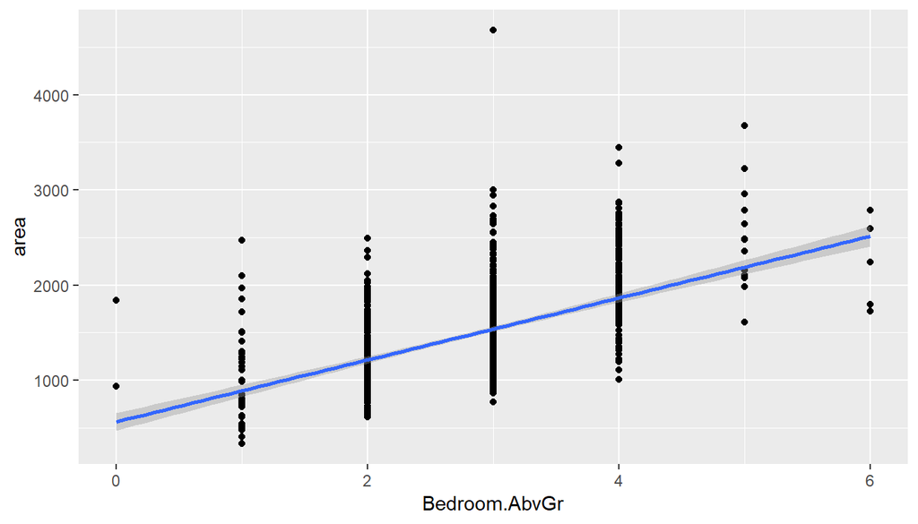

```r
# type your code for Question 13 here, and Knit
ggplot(data = ames_train, aes(x = Bedroom.AbvGr, y = area)) +
  geom_point() +
  stat_smooth(method = "lm")
```

14. Of the people who have unfinished basements, what is the average square footage of the unfinished basement?
    1. 590.36
    2. 595.25
    3. 614.37
    4. 681.94

```r
# type your code for Question 14 here, and Knit
unf_bsmt_ames <- ames_train %>%
  filter(!is.na(Bsmt.Unf.SF) & Bsmt.Unf.SF > 0) %>%
  dplyr::select(Bsmt.Unf.SF)
summary(unf_bsmt_ames)
```

```
##   Bsmt.Unf.SF
##  Min.   :  17.0
##  1st Qu.: 271.5
##  Median : 515.5
##  Mean   : 595.3
##  3rd Qu.: 809.5
##  Max.   :2336.0
```